# WORLD CUP PENALTY SHOOTOUTS ANALYSIS AND WINNER PREDICTION

In this notebook, I will attempt to go for an exploratory data analysis of the penalty shootouts from worlcup since it has started up to the 2022 edition.

First will take a look at the data (which is a classic),

then we'll try to visualize the data to:

# Goal post zones

- See which goal post zone has the highest chances of penalty conversion
- See whether these differences are statistically significant to make any kind of inference
- Look at both conversion rates and zone preferences in terms of zone per penalty number

# Country Performances

- Take a deeper dive to compare country performances in terms of conversion rates and wins

# Dexterity trends

- Compare conversion rates from a dexterity stand point
- Map out conversion rates and number of shots per foot (left vs right) per goalpost zone

# Goal keeper trends

- Take a look at goal keeper preferences dive-wise
- see which country has the most saves across all competitions

# Elimination predictions using K-Nearest neighbors

# Winner Prediction with KNN based on Country key features

Let's import our libraries shall we

```python
import pandas as pd
import numpy as np
import seaborn as sns
import matplotlib.pyplot as plt
import cufflinks as cf
import warnings

%matplotlib inline
```

Let's get the path to where our notebook directory is located, cuz sometimes I struggle to recall it ^^'

```python
import os
print(os.getcwd())
```

```
/Users/macbookpro/Documents
```

```python
cf.go_offline()
```

```python
# I hate warnings, they never fail to make me look like the noob I actually am!
warnings.filterwarnings("ignore")
```

This is the latest dataset that was uploaded to Kaggle by Pablo L.Landeros and then later updated by Jan Dimovski to include 2022 World Cup penalty shoutouts, here's the link to it:

https://www.kaggle.com/datasets/pablollanderos33/world-cup-penalty-shootouts/discussion

```python
df = pd.read_csv('WorldCupShootouts 2.csv')
```

# SECTION I : THE PANDAS RITUAL

```python
print(df.shape)
```

```
(320, 9)
```

```python
df.head()
```

|  | Game_id | Team | Zone | Foot | Keeper | OnTarget | Goal | Penalty_Number | Elimination |
| --- | --- | --- | --- | --- | --- | --- | --- | --- | --- |
| 0 | 1 | FRA | 7 | R | R | 1 | 1 | 1 | 0 |
| 1 | 1 | GER | 9 | R | C | 1 | 1 | 2 | 0 |
| 2 | 1 | FRA | 6 | R | L | 1 | 1 | 3 | 0 |
| 3 | 1 | GER | 2 | R | C | 1 | 1 | 4 | 0 |
| 4 | 1 | FRA | 9 | R | L | 1 | 1 | 5 | 0 |

```python
df.info()
```

```
<class 'pandas.core.frame.DataFrame'>
RangeIndex: 320 entries, 0 to 319
Data columns (total 9 columns):
 #   Column          Non-Null Count  Dtype
---  ------          --------------  -----
 0   Game_id         320 non-null    int64
 1   Team            320 non-null    object
 2   Zone            320 non-null    int64
 3   Foot            320 non-null    object
 4   Keeper          320 non-null    object
 5   OnTarget        320 non-null    int64
 6   Goal            320 non-null    int64
 7   Penalty_Number  320 non-null    int64
 8   Elimination     320 non-null    int64
dtypes: int64(6), object(3)
memory usage: 22.6+ KB
```

To get more specific on the data feel free to check out the kaggle dataset description as it provides a detailed explanation for each column, I'll showcase what the more ambiguous ones mean such as 'Keeper' and 'Zone' with an imshow, trust me u'll understand when you see it!

[figure not shown]

```python
fig, ax = plt.subplots(1, 2, figsize=(12, 4))

image1 = plt.imread('goal post.png')
image2 = plt.imread('goal pos.png')

ax[0].imshow(image1)
ax[0].set_title("Zones", fontdict={'fontsize':16, 'fontweight':'bold'})
ax[1].imshow(image2)
ax[1].set_title("Keeper", fontdict={'fontsize':16, 'fontweight':'bold'})
```

Phew! No null values...!

```python
df.isna().sum()
```

```
Game_id           0
Team              0
Zone              0
Foot              0
Keeper            0
OnTarget          0
Goal              0
Penalty_Number    0
Elimination       0
dtype: int64
```

The size of the dataset, as well as the nature and proportion of missing data are an important factor to be taken into consideration in order to make an informed decision on how to handle those missing values, either by applying mean imputation, removing it altogether or sometimes by just taking a wild guess! (OK that last one's a joke... if this project notebook turns out to be trash, might as well get a laugh or two)

```python
missing_data = 0/df.shape[0]

print(f"We have {missing_data:.2%} missing data")
```

```
We have 0.00% missing data
```

this is just some fancy Aikedo to properly locate where NA values are! but since we don't have any, this heatmap is useless...

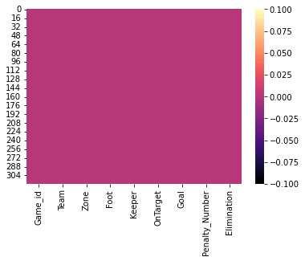

```python
sns.heatmap(pd.isnull(df), cmap='magma')
```

```python
df_imp = df.copy()
df_imp
```

|  | Game_id | Team | Zone | Foot | Keeper | OnTarget | Goal | Penalty_Number | Elimination |
| --- | --- | --- | --- | --- | --- | --- | --- | --- | --- |
| 0 | 1 | FRA | 7 | R | R | 1 | 1 | 1 | 0 |
| 1 | 1 | GER | 9 | R | C | 1 | 1 | 2 | 0 |
| 2 | 1 | FRA | 6 | R | L | 1 | 1 | 3 | 0 |
| 3 | 1 | GER | 2 | R | C | 1 | 1 | 4 | 0 |
| 4 | 1 | FRA | 9 | R | L | 1 | 1 | 5 | 0 |
| ... | ... | ... | ... | ... | ... | ... | ... | ... | ... |
| 315 | 35 | ARG | 8 | L | R | 1 | 1 | 4 | 0 |
| 316 | 35 | FRA | 7 | R | L | 0 | 0 | 5 | 0 |
| 317 | 35 | ARG | 7 | R | L | 1 | 1 | 6 | 0 |
| 318 | 35 | FRA | 2 | R | L | 1 | 1 | 7 | 0 |
| 319 | 35 | ARG | 7 | R | R | 1 | 1 | 8 | 1 |

320 rows × 9 columns

```python
df_imp['Zone'] = df_imp["Zone"].astype('int64')
```

# GOAL POST ZONES ANALYSIS

here we're taking a look at the shots scored vs those missed as well as the distributions of shots by location to see if any location prforms better than others in terms of Goals scored.

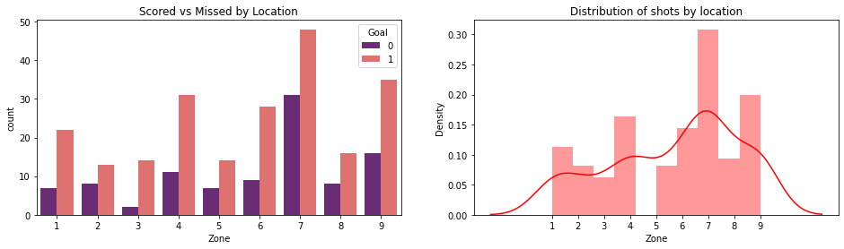

```python
fig, axes = plt.subplots(1,  2, figsize=(16, 4))
plt.xticks(np.arange(1, 10))
sns.countplot(data=df_imp, x = df["Zone"], ax=axes[0], hue='Goal', palette='magma')
axes[0].set_title("Scored vs Missed by Location")


sns.distplot(df_imp["Zone"], ax=axes[1], color='red')
axes[1].set_title("Distribution of shots by location")
```

We can already see that location 3 has far less missed shots, but also has the least amount of total shots! however, compared to zone 5, which aggregates to roughly the closest amount of total shots (21 for 5 vs 16 for 3), zone 5 has at least twice the amount of shots missed

We'll group by the the dataframe by goal post zones to calculate the % scored also known as Conversion Rate

```python
scored = df_imp.groupby('Zone').agg({'Zone':'count', 'Goal':'sum'})
```

```python
scored["% scored"] = round(scored["Goal"] / scored["Zone"], 2)
```

```python
scored.columns = ['Zone Count', 'Goals', '% scored']
```

```python
scored.reset_index(inplace=True)
```

```python
scored
```

|  | Zone | Zone Count | Goals | % scored |
| --- | --- | --- | --- | --- |
| 0 | 1 | 29 | 22 | 0.76 |
| 1 | 2 | 21 | 13 | 0.62 |
| 2 | 3 | 16 | 14 | 0.88 |
| 3 | 4 | 42 | 31 | 0.74 |
| 4 | 5 | 21 | 14 | 0.67 |
| 5 | 6 | 37 | 28 | 0.76 |
| 6 | 7 | 79 | 48 | 0.61 |
| 7 | 8 | 24 | 16 | 0.67 |
| 8 | 9 | 51 | 35 | 0.69 |

Let's plot out a heatmap showing the amount of shots per goal post zone as partitioned in the Goal Post Image, to get a nice looking visualization of conversion rates by Zone!

[figure not shown]

```python
# Let's draw a map of each location as a grid with the metrics inside

heatmap_data = scored['% scored'].values.reshape(3, 3)

# Create a color palette for conditional formatting
cmap = sns.cm.rocket_r  # You can choose any colormap you like

# Create the grid plot
fig, ax = plt.subplots(2, 1, figsize=(12, 12))
sns.heatmap(heatmap_data, annot=True, annot_kws=({'fontsize':18,'fontweight':'bold'}),
            fmt=".0%", cmap=cmap, cbar=True, ax=ax[1])

# Set x and y axis labels
ax[1].set_xlabel('Goal post Width')
ax[1].set_ylabel('Goal Post Height')

# Set tick labels
ax[1].set_xticklabels(['bottom left', 'down middle', 'bottom right'])
ax[1].set_yticklabels(['top left', 'middle left', 'bottom left'], rotation='horizontal')
ax[1].set_title('% scored')

ax[0].imshow(image1)
```

Here we can see that penalties shot on goal keeper's left hand side perform slightly better than those shot on the right or middle! More importantly Zone 3, which corresponds the top right corner, shows a conversion rate of 88% which is quite impressive! Keep in mind that we're talking about a sample here so we still need some work to do to infere this information upon the entire polulation of... Penalty shots.

```python
df_imp['Goal'] = df_imp['Goal'].astype('int64')
```

```python
gx = df_imp[['Zone','Goal', 'Penalty_Number']].groupby(by=['Zone', 'Penalty_Number']).agg({'Penalty_Number':'count', 'Goal': 'sum'})
```

```python
gx["Conversion"] = round(gx['Goal'] / gx['Penalty_Number'], 2)
```

Now that we took a look at conversion rate per goal post zone! it'd be more interesting if we visualize the same heatmap but per Penalty number this time, to see if there's any interesting trends regarding zone x penalty number

```python
cn = gx.unstack().iloc[:,24:34]
cn
```

| Penalty_Number Zone | Conversion 1 | Conversion 2 | Conversion 3 | Conversion 4 | Conversion 5 | Conversion 6 | Conversion 7 | Conversion 8 | Conversion 9 | Conversion 10 |
| --- | --- | --- | --- | --- | --- | --- | --- | --- | --- | --- |
| 1 | 1.00 | 0.67 | 1.00 | 0.50 | 0.75 | 0.67 | 1.00 | 0.67 | 0.67 | 1.00 |
| 2 | 0.62 | 1.00 | 0.00 | 1.00 | NaN | 0.00 | 0.67 | NaN | 0.50 | 0.00 |
| 3 | 1.00 | 1.00 | 1.00 | NaN | NaN | 1.00 | 0.00 | 1.00 | 1.00 | NaN |
| 4 | 0.50 | 0.75 | 0.75 | 1.00 | 0.67 | 0.60 | 0.83 | 0.67 | 0.00 | 1.00 |
| 5 | 0.50 | 0.67 | 1.00 | 1.00 | 0.75 | 0.00 | NaN | 0.33 | 1.00 | 0.50 |
| 6 | 1.00 | 1.00 | 0.75 | 0.75 | 1.00 | 0.67 | 0.00 | 1.00 | 1.00 | 0.33 |
| 7 | 0.75 | 0.60 | 0.17 | 0.67 | 0.42 | 0.82 | 0.88 | 0.36 | 0.71 | 1.00 |
| 8 | 1.00 | 0.50 | 1.00 | 0.67 | 1.00 | 0.67 | 0.40 | 1.00 | 0.00 | 1.00 |
| 9 | 0.67 | 0.75 | 0.71 | 0.57 | 1.00 | 0.60 | 1.00 | 0.00 | 0.50 | 1.00 |

```python
gn = gx.unstack().iloc[:,12:22]
```

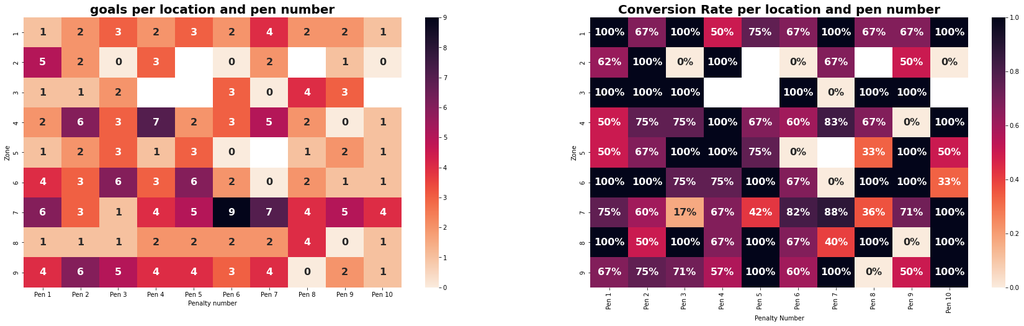

```python
# pen number per location heatmap
fig_h, ax_h = plt.subplots(1, 2, figsize=(30, 8))
sns.heatmap(gn, cmap=cmap, annot=True,annot_kws=({'fontsize':16, 'fontweight': 'bold'}),
            ax=ax_h[0])

labs = []
for i in range(1, 11):
    labs.append('Pen '+ str(i))

ax_h[0].set_xticklabels(labs)
ax_h[0].set_title('goals per location and pen number',fontdict={'fontsize':20, 'fontweight':'bold'})
ax_h[0].set_xlabel('Penalty number')

sns.heatmap(cn, cmap=cmap, annot=True, annot_kws=({'fontsize':16, 'fontweight': 'bold'}),fmt = '.0%',
            ax=ax_h[1])

ax_h[1].set_xticklabels(labs)
ax_h[1].set_title('Conversion Rate per location and pen number', fontdict={'fontsize':20, 'fontweight':'bold'})
ax_h[1].set_xlabel('Penalty Number')
```

these heatmaps show how conversion rate per zone varies with respect to the order of penalties, it's important to takee into consideration the total number of penalties taken when reading through the conversion rate for a given zone x peenalty number.

```python
import plotly.subplots as sp
import plotly.graph_objs as go
import pandas as pd

# Create subplots
fig = sp.make_subplots(specs=[[{'secondary_y': True}]])

# Add line plot to the first y-axis
line_trace = go.Scatter(x=scored["Zone"], y=scored['% scored'], mode='lines+markers',
                        line=dict(dash='dash', color='red'),name='% Scored')
fig.add_trace(line_trace, secondary_y=False)

bar_trace = go.Bar(x=scored['Zone'], y=scored['Zone Count'], name='Shots Taken',
                   marker=dict(color='rgba(255, 0, 23, 0.4)'))

fig.add_trace(bar_trace, secondary_y=True)


# Update axis labels
fig.update_xaxes(title_text='Goal Post Zones')
fig.update_yaxes(title_text='% Scored', secondary_y=False, showgrid=False,range=[0, 1], zeroline=False)
fig.update_yaxes(title_text='Shots', showgrid=False,secondary_y=True, zeroline=False)

# Update layout
fig.update_layout(title_text='Shots per Zone vs Conversion Rate', hoverlabel=dict(bgcolor='rgba(200, 0, 0, 0.1)'),
                  plot_bgcolor='rgba(0, 0, 0, 0)',
                  paper_bgcolor='rgba(0, 0, 0, 0)')
```

[interactive chart not shown]

This plot summerizes the shots taken by Zone as well as their respective conversion rates on a parallel lineplot. As seen before, zone 3, 6, 1 and 4 have the highest conversion rates in 88%, 76%, 76%, and 74% respectively.

in the next section we'll perform a test for this observation to see whether we can infere any information worth generalizing on the best spots to aim for when taking a penalty shot.

# Hypothesis testing with Chi2 Squared

```python
# Importing libraries for Chi2 Test
from scipy.stats import chi2_contingency
```

```python
# Adding missed shots to build Contingency Tables

scored['missed'] = (scored['Zone Count'] - scored['Goals']).astype('int64')
scored
```

|  | Zone | Zone Count | Goals | % scored | missed |
| --- | --- | --- | --- | --- | --- |
| 0 | 1 | 29 | 22 | 0.76 | 7 |
| 1 | 2 | 21 | 13 | 0.62 | 8 |
| 2 | 3 | 16 | 14 | 0.88 | 2 |
| 3 | 4 | 42 | 31 | 0.74 | 11 |
| 4 | 5 | 21 | 14 | 0.67 | 7 |
| 5 | 6 | 37 | 28 | 0.76 | 9 |
| 6 | 7 | 79 | 48 | 0.61 | 31 |
| 7 | 8 | 24 | 16 | 0.67 | 8 |
| 8 | 9 | 51 | 35 | 0.69 | 16 |

```python
# Building our contingency Table
contingency_table = scored[['Goals', 'missed']].values
```

```python
chi2, p_value, _, _ = chi2_contingency(contingency_table)
```

```python
# Setting the significance level at 5%
significance_level = 0.05
```

```python
# Calculating degrees of freedom (R - 1) x (C - 1)
degrees_of_freedom = (contingency_table.shape[0] - 1)*(contingency_table.shape[1] - 1)
print(f"we have {degrees_of_freedom} for this test")
```

```
we have 8 for this test
```

```python
print(f"Chi-squared statistic: {chi2:.3}")
print(f"p-value: {p_value:.3%}")
```

```
Chi-squared statistic: 7.55
p-value: 47.847%
```

```python
# decision
if significance_level > p_value:
    print("Reject the null hypothesis")
else:
    print("Fail to reject the null hypothesis")
```

```
Fail to reject the null hypothesis
```

This result means that there's 47% that the 88% is just due to random events or other reasons tthat fall out of reach of this dataset

# COUNTRY PERFORMANCES

```python
countries = df_imp.groupby('Team').agg({'Team': 'count','Goal': 'sum'})
```

```python
countries.columns = ['Shots Taken', 'Goals']
```

```python
countries.reset_index(inplace=True)
```

```python
countries["Conversion Rate"] = round(countries["Goals"] / countries["Shots Taken"], 2)
```

```python
co = countries.sort_values("Shots Taken", axis=0, ascending=False).head(10)
co
```

|  | Team | Shots Taken | Goals | Conversion Rate |
| --- | --- | --- | --- | --- |
| 0 | ARG | 31 | 25 | 0.81 |
| 11 | FRA | 24 | 17 | 0.71 |
| 2 | BRA | 22 | 15 | 0.68 |
| 17 | ITA | 20 | 13 | 0.65 |
| 9 | ENG | 19 | 10 | 0.53 |
| 29 | SPA | 19 | 13 | 0.68 |
| 12 | GER | 18 | 17 | 0.94 |
| 7 | CRO | 18 | 14 | 0.78 |
| 15 | HOL | 12 | 8 | 0.67 |
| 6 | CRA | 10 | 8 | 0.80 |

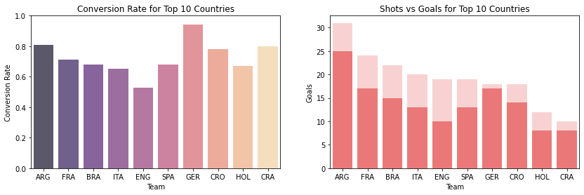

```python
fig2, axes2 = plt.subplots(1, 2, figsize=(14, 4))

sns.barplot(data=co, x='Team', y='Conversion Rate', palette='magma', alpha=0.7, ax=axes2[0])
axes2[0].set_title("Conversion Rate for Top 10 Countries")
axes2[0].set_ylim(0,1)

sns.barplot(data=co, x='Team', y='Shots Taken', color='red', alpha=0.2, ax=axes2[1])
axes2[1].set_title('Shots Taken per Country')

sns.barplot(data=co, x='Team', y='Goals', color='red',  alpha=0.5, ax=axes2[1])
axes2[1].set_title('Shots vs Goals for Top 10 Countries')
```

# WINNERS AND LOSERS

```python
win = df_imp[['Game_id','Team', 'Goal']].groupby(by=['Game_id', 'Team']).sum()
win.head(6)
```

| Game_id | Team | Goal |
| --- | --- | --- |
| 1 | FRA | 4 |
|  | GER | 5 |
| 2 | BRA | 3 |
|  | FRA | 4 |
| 3 | GER | 4 |
|  | MEX | 1 |

```python
win.reset_index(inplace=True)
```

```python
winners = []
for i, value in enumerate(win['Goal']):
    if i % 2 == 0:
        oponent = win['Goal'].iloc[i + 1]
        if value > oponent:
            winners.append(win['Team'].iloc[i])
        else:
            winners.append(win['Team'].iloc[i + 1])

print(winners)
```

```
['GER', 'FRA', 'GER', 'BEL', 'IRE', 'ARG', 'ARG', 'GER', 'BUL', 'SWE', 'BRA', 'ARG', 'FRA', 'BRA', 'SPA', 'KOR', 'UKR', 'GER', 'POR', 'ITA', 'PAR', 'URU', 'BRA', 'CRA', 'HOL', 'ARG', 'RUS', 'CRO', 'ENG', 'CRO', 'CRO', 'MAR', 'CRO', 'ARG', 'ARG']
```

```python
uniwin = set(winners)
print(uniwin)
```

```
{'BUL', 'ENG', 'UKR', 'BRA', 'SPA', 'IRE', 'GER', 'HOL', 'MAR', 'RUS', 'URU', 'FRA', 'POR', 'CRA', 'BEL', 'KOR', 'CRO', 'ITA', 'PAR', 'SWE', 'ARG'}
```

```python
nb_wins = 0
winning_team = []
nb_wins_team = []
for team in uniwin:
    for c in winners:
        if team == c:
            nb_wins += 1
    winning_team.append(team)
    nb_wins_team.append(nb_wins)
    nb_wins = 0
```

```python
w_teams = pd.DataFrame({"Team":winning_team, 'Number Of Wins':nb_wins_team})
```

```python
w_teams.sort_values('Number Of Wins', ascending=False, inplace=True)
```

```python
w_teams.reset_index(drop=True)

def get_participation(w_teams, win):
    participations = []
    counter = 0
    for i, team in enumerate(w_teams):
        counter = 0
        for j, team2 in enumerate(win):
            if team2 == team:
                counter += 1
        participations.append(counter)

    return participations
```

```python
participations = get_participation(w_teams['Team'], win['Team'])
participations
```

```
[7, 4, 4, 5, 5, 1, 1, 1, 4, 1, 1, 2, 1, 4, 2, 1, 3, 2, 4, 1, 1]
```

```python
w_teams["Participations"] = participations
w_teams.head(10)
```

|  | Team | Number Of Wins | Participations |
| --- | --- | --- | --- |
| 20 | ARG | 6 | 7 |
| 6 | GER | 4 | 4 |
| 16 | CRO | 4 | 4 |
| 3 | BRA | 3 | 5 |
| 11 | FRA | 2 | 5 |
| 12 | POR | 1 | 1 |
| 19 | SWE | 1 | 1 |
| 18 | PAR | 1 | 1 |
| 17 | ITA | 1 | 4 |
| 15 | KOR | 1 | 1 |

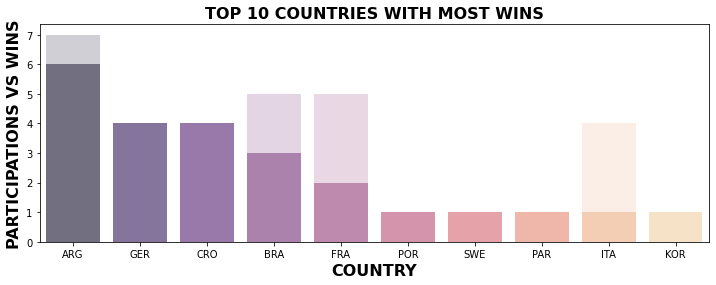

```python
fig4, ax4 = plt.subplots(figsize=(12, 4))
sns.barplot(data=w_teams.head(10), x='Team', y='Participations', palette='magma', alpha=0.2, ax=ax4)
ax4.set_title('Top 10 Countries with Most wins'.upper(),fontdict={'fontsize':16, 'fontweight':'bold'})

sns.barplot(data=w_teams.head(10), x='Team', y='Number Of Wins', palette='magma', alpha=0.5, ax=ax4)
ax4.set_xlabel('COUNTRY', fontdict={'fontsize':16, 'fontweight':'bold'})
ax4.set_ylabel('Participations vs Wins'.upper(), fontdict={'fontsize':16, 'fontweight':'bold'})
```

# BEST VS WORST : GERMANY VS ITALY

```python
ger_v_spa = w_teams[(w_teams['Team'] == 'ITA') | (w_teams['Team'] == 'GER')]
```

```python
fig = sp.make_subplots(specs=[[{'secondary_y': True}]])

# Add line plot to the first y-axis
bar1_trace = go.Bar(x=ger_v_spa["Team"], y=ger_v_spa['Participations'], name='PARTICIPATIONS',
                   marker=dict(color='rgba(48, 213, 200, 0.4)'))
fig.add_trace(bar1_trace, secondary_y=False)

bar2_trace = go.Bar(x=ger_v_spa["Team"], y=ger_v_spa['Number Of Wins'], name='WINS',
                   marker=dict(color='rgba(48, 213, 200, 0.8)'))
fig.add_trace(bar2_trace, secondary_y=True)

# Update layout
fig.update_layout(title_text='GERMANY VS SPAIN', hoverlabel=dict(bgcolor='rgba(255, 190, 0, 0.1)'),
                  plot_bgcolor='rgba(0, 0, 0, 0)',
                  paper_bgcolor='rgba(0, 0, 0, 0)')
```

[interactive chart not shown]

# LET'S DISCUSS POLITICS : LEFT VS RIGHT

```
    # how many left shots scored vs right
    # how many left shots on target vs right
    # conversion rate per foot
    # heatmap left, right vs position
    #
```

```python
# reminding myself of dataframe columns
df_imp.columns
```

```
Index(['Game_id', 'Team', 'Zone', 'Foot', 'Keeper', 'OnTarget', 'Goal',
       'Penalty_Number', 'Elimination'],
      dtype='object')
```

First things first, we'll try and see how different dexterities (leeft vs right) perform against each other, we'll make two seperate plots, one for the total goals score,and the other for the number of shots.

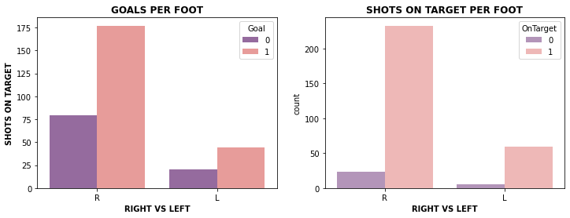

```python
fig, ax = plt.subplots(1, 2, figsize=(12, 4))

# Goals scored per foot countplot
sns.countplot(x=df_imp['Foot'], hue=df_imp['Goal'],  palette='magma', alpha=0.7, ax=ax[0])
ax[0].set_title('GOALS PER FOOT',fontdict=({'fontweight':'bold'}))
ax[0].set_xlabel('RIGHT VS LEFT',fontdict=({'fontweight':'bold'}))
ax[0].set_ylabel('GOALS SCORED',fontdict=({'fontweight':'bold'}))

# Countplot for shots on target per foot
sns.countplot(x=df_imp['Foot'], hue=df_imp['OnTarget'], palette='magma', alpha=0.5, ax=ax[1])
ax[1].set_title('SHOTS ON TARGET PER FOOT',fontdict=({'fontweight':'bold'}))
ax[1].set_xlabel('RIGHT VS LEFT',fontdict=({'fontweight':'bold'}))
ax[0].set_ylabel('SHOTS ON TARGET',fontdict=({'fontweight':'bold'}))
```

```python
# Grouping dataframe by foot (left vs right) to calculate the number of shots and goals per foot
lr = df_imp[['Foot', 'Goal']].groupby('Foot').agg({'Foot':'count' , 'Goal':'sum'})
```

```python
# Renaming our foot dataframe columns
lr.columns = ['Shot count',  'Goals']
```

```python
# Calculating Conversion Rates per foot
lr['Conversion Rate'] = round(lr['Goals'] / lr['Shot count'], 2)
```

```python
lr
```

| Foot | Shot count | Goals | Conversion Rate |
| --- | --- | --- | --- |
| L | 64 | 44 | 0.69 |
| R | 256 | 177 | 0.69 |

Whether a player is a right footed or a lefty, both seem to have the same conversion rate 69% vs 69% -- what a coincidence...not 68... but 69 =)

it's worth noting that overall, there are right footed players than left footed, this mainly the reeason why we can see that a lot more shots are taken by righties.

In the next step we'll try totake a look at player zone preferences depending on whether they are left or right footed

```python
# let's make a new dataframe that groups foot by zone
lrhm = df_imp[['Foot', 'Goal', 'Zone']].groupby(by=['Foot', 'Zone']).agg({'Foot':'count',
                                                                           'Goal':'sum'})
```

```python
# Another Conversion rate calculation
lrhm['Conversion Rate'] = round(lrhm['Goal'] / lrhm['Foot'], 2)
```

Here we are unstacking to map zone and foot against each other and using some Numpy action to get the slice where the goals scored are

```python
# goals per foot per zone
lrhm.unstack().iloc[:,:9]
```

| Zone Foot | Foot 1 | Foot 2 | Foot 3 | Foot 4 | Foot 5 | Foot 6 | Foot 7 | Foot 8 | Foot 9 |
| --- | --- | --- | --- | --- | --- | --- | --- | --- | --- |
| L | 3 | 2 | 5 | 8 | 5 | 7 | 11 | 10 | 13 |
| R | 26 | 19 | 11 | 34 | 16 | 30 | 68 | 14 | 38 |

Here we are using the same Numpy action to get the slice where the Conversion Rates are

```python
# Conversion rates per zone per foot
lrhm.unstack().iloc[:,18:]
```

| Zone Foot | Conversion Rate 1 | Conversion Rate 2 | Conversion Rate 3 | Conversion Rate 4 | Conversion Rate 5 | Conversion Rate 6 | Conversion Rate 7 | Conversion Rate 8 | Conversion Rate 9 |
| --- | --- | --- | --- | --- | --- | --- | --- | --- | --- |
| L | 0.67 | 0.50 | 1.00 | 0.75 | 1.00 | 0.57 | 0.64 | 0.60 | 0.62 |
| R | 0.77 | 0.63 | 0.82 | 0.74 | 0.56 | 0.80 | 0.60 | 0.71 | 0.71 |

In this final plot, we'll try and visualize the two dataframes we made above on two separate heatmaps, to get a sense of how both preference and performance vary from foot to foot! Also it could be a useful blueprint for professional players to help them out with penalty shot taking.

[figure not shown]

```python
fig, ax = plt.subplots(3, 1, figsize=(28, 18))

sns.heatmap(lrhm.unstack().iloc[:,18:], cmap='viridis', fmt= ".0%",annot=True, annot_kws={"fontsize":16,
                                                                             'fontweight':'bold'}, ax=ax[0])

ax[0].set_xticklabels(np.arange(1, 10).astype("str"), fontdict={'fontsize':12, 'fontweight':'bold'})
ax[0].set_yticklabels(['L', 'R'], fontdict={'fontsize':24, 'fontweight':'bold'})
ax[0].set_xlabel("ZONES",fontdict={'fontsize':16, 'fontweight':'bold'})
ax[0].set_ylabel("DEXTERITY",fontdict={'fontsize':16, 'fontweight':'bold'})
ax[0].set_title('ZONE SUCCES RATE BY DEXTERITY', fontdict={'fontsize':14, 'fontweight':'bold'})

sns.heatmap(lrhm.unstack().iloc[:,:9], cmap='viridis',annot=True, annot_kws={"fontsize":16,
                                                                             'fontweight':'bold'}, fmt='d',ax=ax[1])

ax[1].set_xticklabels(np.arange(1, 10).astype("str"), fontdict={'fontsize':12, 'fontweight':'bold'})
ax[1].set_yticklabels(['L', 'R'], fontdict={'fontsize':24, 'fontweight':'bold'})
ax[1].set_xlabel("ZONES",fontdict={'fontsize':16, 'fontweight':'bold'})
ax[1].set_ylabel("DEXTERITY",fontdict={'fontsize':16, 'fontweight':'bold'})
ax[1].set_title('ZONE PREFERENCE BY DEXTERITY', fontdict={'fontsize':14, 'fontweight':'bold'})

ax[2].imshow(image)
```

# EH! WHAT YOU DOING GOALIE?

```python
df_imp.head(3)
```

|  | Game_id | Team | Zone | Foot | Keeper | OnTarget | Goal | Penalty_Number | Elimination |
| --- | --- | --- | --- | --- | --- | --- | --- | --- | --- |
| 0 | 1 | FRA | 7 | R | R | 1 | 1 | 1 | 0 |
| 1 | 1 | GER | 9 | R | C | 1 | 1 | 2 | 0 |
| 2 | 1 | FRA | 6 | R | L | 1 | 1 | 3 | 0 |

```python
gl = df_imp.copy()
```

Due to lack of data, we will be assuming that any shots on target that haven't resulted in a goal were saved by the goalkeeper, although this is not necessarily true becausee there's a chance that the ball has hit the post.

```python
gl["IsSaved"] = np.where((gl['OnTarget']==1) & (gl['Goal'] == 0),1, 0)
```

```python
glagg = gl.groupby(by=['Game_id','Team']).agg({'OnTarget':'count', 'Goal':'sum', 'IsSaved':'sum'})
```

```python
l = []
lister = list(glagg['IsSaved'])
for i in range(len(lister)):
    if i % 2 == 0:
        l.append(lister[i + 1])
        l.append(lister[i])
print(l)
```

```
[1, 2, 0, 1, 2, 0, 1, 0, 1, 0, 2, 1, 2, 0, 0, 2, 2, 1, 0, 2, 1, 1, 2, 1, 1, 1, 2, 0, 0, 2, 1, 0, 1, 2, 0, 2, 0, 3, 0, 0, 0, 0, 0, 2, 2, 1, 1, 0, 0, 2, 2, 0, 2, 0, 3, 2, 1, 1, 1, 1, 3, 0, 1, 2, 0, 1, 2, 0, 1, 0]
```

```python
glagg["IsSaved"] = l
```

```python
glagg.reset_index(inplace=True)
```

```python
agg_saved = glagg[['Team','OnTarget','Goal', 'IsSaved']].groupby('Team').sum()
```

```python
agg_saved.reset_index(inplace=True)
```

```python
agg_saved.sort_values('IsSaved', ascending=False, inplace=True)
```

```python
agg_saved.head(8)
```

|  | Team | OnTarget | Goal | IsSaved |
| --- | --- | --- | --- | --- |
| 0 | ARG | 31 | 25 | 11 |
| 7 | CRO | 18 | 14 | 8 |
| 12 | GER | 18 | 17 | 8 |
| 2 | BRA | 22 | 15 | 5 |
| 28 | RUS | 9 | 7 | 3 |
| 25 | POR | 5 | 3 | 3 |
| 11 | FRA | 24 | 17 | 3 |
| 15 | HOL | 12 | 8 | 2 |

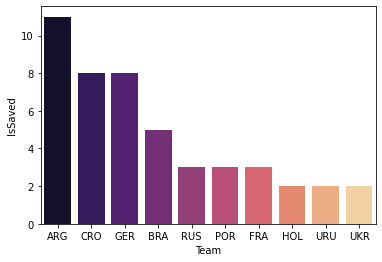

```python
sns.barplot(data=agg_saved.head(10), x='Team', y='IsSaved', palette='magma')
```

```python
df_imp["Keeper"] = df_imp['Keeper'].apply(lambda x:x.upper())
```

```python
keep = df_imp[['Zone','Keeper']].groupby('Keeper').count()
```

```python
keep
```

| Keeper | Zone |
| --- | --- |
| C | 37 |
| L | 153 |
| R | 130 |

```python
L = keep.reset_index(drop=True).loc[1,'Zone']
```

```python
C = keep.reset_index(drop=True).loc[0,'Zone']
```

```python
R = keep.reset_index(drop=True).loc[2,'Zone']
```

```python
k_arr = np.array([[L, C, R]])
k_ = k_arr / np.sum(k_arr)
k_
```

```
array([[0.478125, 0.115625, 0.40625 ]])
```

[figure not shown]

```python
fig, ax = plt.subplots(1, 2,figsize=(20,4))

sns.heatmap(k_, annot=True, annot_kws={'fontsize':14,'fontweight':'bold'},fmt='.2%', cmap='magma', ax=ax[0])

goal_pos = plt.imread('goal pos.png')
ax[0].set_xticklabels(['L', 'C', 'R'], fontdict={'fontsize': 18, 'fontweight':'bold'})
ax[0].set_yticklabels(['Goal Post Heatmap'], fontdict={'fontsize': 14})

ax[1] = plt.imshow(goal_pos)
```

```python
gl.columns
```

```
Index(['Game_id', 'Team', 'Zone', 'Foot', 'Keeper', 'OnTarget', 'Goal',
       'Penalty_Number', 'Elimination', 'IsSaved'],
      dtype='object')
```

```python
saves = gl[['Zone', 'IsSaved']].groupby('Zone').agg({'Zone':'count','IsSaved':'sum'})
```

```python
saves['% Saved'] = round(saves['IsSaved'] / saves['Zone'], 2)
```

```python
saves_heatmap = saves.iloc[:,2:].values.reshape(3, 3)
```

```python
saves_heatmap
```

```
array([[0.03, 0.05, 0.  ],
       [0.21, 0.33, 0.22],
       [0.29, 0.33, 0.27]])
```

[figure not shown]

```python
fig, ax = plt.subplots(1, 2, figsize=(24, 6))

sns.heatmap(saves_heatmap, cmap='magma', annot=True, annot_kws={'fontsize':24,'fontweight':'bold'}, fmt='.0%', ax=ax[0])
ax[0].set_title('SAVE PERCENTAGE PER ZONE', fontdict={'fontsize':16,'fontweight':'bold'})

ax[0].set_xticklabels(['bottom left', 'down middle', 'bottom right'], fontdict={'fontsize':14})
ax[0].set_yticklabels(['top left', 'middle left', 'bottom left'], rotation='horizontal', fontdict={'fontsize':14})

ax[1] = plt.imshow(image2)
```

```python
1 - (heatmap_data + saves_heatmap)
```

```
array([[0.21, 0.33, 0.12],
       [0.05, 0.  , 0.02],
       [0.1 , 0.  , 0.04]])
```

# LET'S FISH FOR TRENDS

```python
dfm = df_imp.copy()
dfm
```

|  | Game_id | Team | Zone | Foot | Keeper | OnTarget | Goal | Penalty_Number | Elimination |
| --- | --- | --- | --- | --- | --- | --- | --- | --- | --- |
| 0 | 1 | FRA | 7 | R | R | 1 | 1 | 1 | 0 |
| 1 | 1 | GER | 9 | R | C | 1 | 1 | 2 | 0 |
| 2 | 1 | FRA | 6 | R | L | 1 | 1 | 3 | 0 |
| 3 | 1 | GER | 2 | R | C | 1 | 1 | 4 | 0 |
| 4 | 1 | FRA | 9 | R | L | 1 | 1 | 5 | 0 |
| ... | ... | ... | ... | ... | ... | ... | ... | ... | ... |
| 315 | 35 | ARG | 8 | L | R | 1 | 1 | 4 | 0 |
| 316 | 35 | FRA | 7 | R | L | 0 | 0 | 5 | 0 |
| 317 | 35 | ARG | 7 | R | L | 1 | 1 | 6 | 0 |
| 318 | 35 | FRA | 2 | R | L | 1 | 1 | 7 | 0 |
| 319 | 35 | ARG | 7 | R | R | 1 | 1 | 8 | 1 |

320 rows × 9 columns

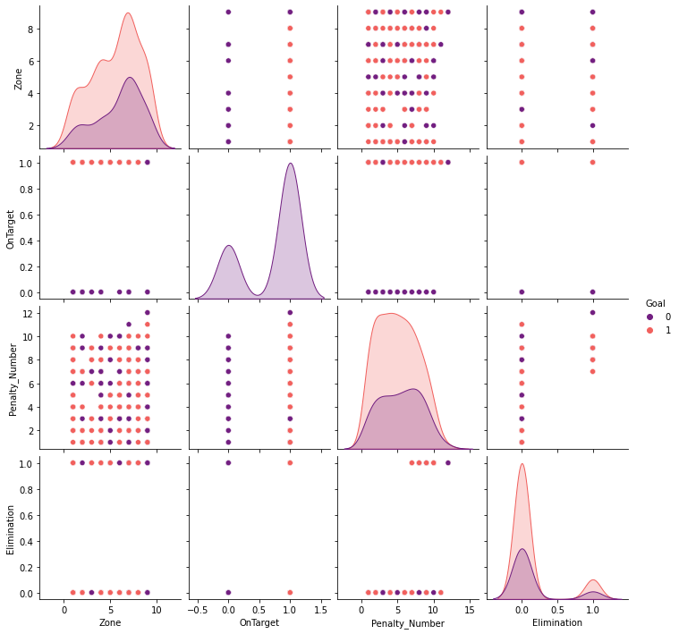

```python
sns.pairplot(dfm.iloc[:,1:], hue='Goal', palette='magma')
```

```python
encoded = pd.get_dummies(dfm[['Team', 'Foot', 'Keeper']], drop_first=True)
```

```python
zone_encode = pd.get_dummies(dfm['Zone'], drop_first=True)
```

```python
encoded_df = pd.concat([dfm,encoded, zone_encode], axis=1)
```

```python
encoded_df.drop(['Game_id', 'Team', 'Zone', 'Foot', 'Keeper'], inplace=True, axis=1)
```

```python
encoded_df.head(10)
```

|  | OnTarget | Goal | Penalty_Number | Elimination | Team_BEL | Team_BRA | Team_BUL | Team_CHI | Team_COL | Team_CRA | ... | Keeper_L | Keeper_R | 2 | 3 | 4 | 5 | 6 | 7 | 8 | 9 |
| --- | --- | --- | --- | --- | --- | --- | --- | --- | --- | --- | --- | --- | --- | --- | --- | --- | --- | --- | --- | --- | --- |
| 0 | 1 | 1 | 1 | 0 | 0 | 0 | 0 | 0 | 0 | 0 | ... | 0 | 1 | 0 | 0 | 0 | 0 | 0 | 1 | 0 | 0 |
| 1 | 1 | 1 | 2 | 0 | 0 | 0 | 0 | 0 | 0 | 0 | ... | 0 | 0 | 0 | 0 | 0 | 0 | 0 | 0 | 0 | 1 |
| 2 | 1 | 1 | 3 | 0 | 0 | 0 | 0 | 0 | 0 | 0 | ... | 1 | 0 | 0 | 0 | 0 | 0 | 1 | 0 | 0 | 0 |
| 3 | 1 | 1 | 4 | 0 | 0 | 0 | 0 | 0 | 0 | 0 | ... | 0 | 0 | 1 | 0 | 0 | 0 | 0 | 0 | 0 | 0 |
| 4 | 1 | 1 | 5 | 0 | 0 | 0 | 0 | 0 | 0 | 0 | ... | 1 | 0 | 0 | 0 | 0 | 0 | 0 | 0 | 0 | 1 |
| 5 | 1 | 0 | 6 | 0 | 0 | 0 | 0 | 0 | 0 | 0 | ... | 1 | 0 | 0 | 0 | 1 | 0 | 0 | 0 | 0 | 0 |
| 6 | 1 | 0 | 7 | 0 | 0 | 0 | 0 | 0 | 0 | 0 | ... | 1 | 0 | 0 | 0 | 0 | 0 | 0 | 0 | 1 | 0 |
| 7 | 1 | 1 | 8 | 0 | 0 | 0 | 0 | 0 | 0 | 0 | ... | 0 | 1 | 0 | 1 | 0 | 0 | 0 | 0 | 0 | 0 |
| 8 | 1 | 1 | 9 | 0 | 0 | 0 | 0 | 0 | 0 | 0 | ... | 1 | 0 | 0 | 0 | 0 | 0 | 0 | 0 | 0 | 1 |
| 9 | 1 | 1 | 10 | 1 | 0 | 0 | 0 | 0 | 0 | 0 | ... | 0 | 0 | 0 | 0 | 0 | 0 | 0 | 0 | 0 | 1 |

10 rows × 49 columns

```python
from sklearn.preprocessing import MinMaxScaler
```

```python
# ****
scaler = MinMaxScaler(feature_range=(-1, 1))
```

```python
# ****
tf = scaler.fit_transform(encoded_df.drop('Elimination', axis=1))
```

```python
tf = scaler.transform(encoded_df.drop('Elimination', axis=1))
```

```python
X = tf
```

```python
Y = encoded_df['Elimination'].values
```

```python
from sklearn.model_selection import train_test_split
```

```python
X_test, X_train, Y_test, Y_train = train_test_split(X, Y, random_state=101, test_size=0.3)
```

```python
from sklearn.neighbors import KNeighborsClassifier
```

```python
KNN = KNeighborsClassifier()
```

```python
KNN.fit(X_train, Y_train)
```

```
KNeighborsClassifier()
```

```python
predictions = KNN.predict(X_test)
```

```python
from sklearn.metrics import confusion_matrix, classification_report,accuracy_score
```

```python
print('**'*30)
print(confusion_matrix(Y_test, predictions))
print('**'*30)
print(classification_report(Y_test, predictions))
print('**'*30)
```

```
[[190   4]
 [ 25   5]]
              precision    recall  f1-score   support

           0       0.88      0.98      0.93       194
           1       0.56      0.17      0.26        30

    accuracy                           0.87       224
   macro avg       0.72      0.57      0.59       224
weighted avg       0.84      0.87      0.84       224
```

```python
print(f' accuracy score is : {accuracy_score(Y_test,predictions):.2%}')
```

```
 accuracy score is : 87.05%
```

# USING THE ELBOW METHOD TO DETECT THE PERFECT VALUE FOR K

```python
error_rate = []
for k in range(1, 41):
    KNN = KNeighborsClassifier(n_neighbors=k)
    KNN.fit(X_train, Y_train)
    pred_i = KNN.predict(X_test)
    error_rate.append(np.mean(pred_i != Y_test))
```

```python
df_errors = pd.DataFrame({"K": list(range(1, 41)),'Errors': error_rate})
```

```python
df_errors.sort_values('Errors', ascending=True).head(5)
```

|  | K | Errors |
| --- | --- | --- |
| 3 | 4 | 0.125000 |
| 1 | 2 | 0.129464 |
| 4 | 5 | 0.129464 |
| 19 | 20 | 0.133929 |
| 23 | 24 | 0.133929 |

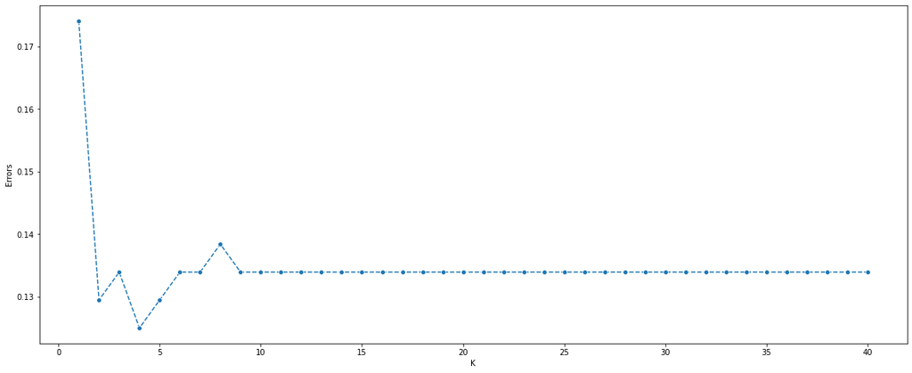

```python
fig, ax = plt.subplots(figsize=(20, 8))

sns.lineplot(data=df_errors, x='K', y='Errors', ax=ax, marker='o', linestyle='--')
```

```python
KNN = KNeighborsClassifier(n_neighbors=4)
KNN.fit(X_train, Y_train)
pred = KNN.predict(X_test)
print(30*'**')
print(confusion_matrix(Y_test, pred))
print(30*'**')
print(classification_report(Y_test, pred))
print(30*'**')
print(f"{accuracy_score(Y_test, pred):.2%}")
```

```
[[193   1]
 [ 27   3]]
              precision    recall  f1-score   support

           0       0.88      0.99      0.93       194
           1       0.75      0.10      0.18        30

    accuracy                           0.88       224
   macro avg       0.81      0.55      0.55       224
weighted avg       0.86      0.88      0.83       224

87.50%
```

# LET'S EXPERIMENT WITH AN AGGREGATED DATAFRAME

Here in this test case we'll aggregate the dataframe by Game and Country and try and squeeze out some more meaningful features in an attempt to make a prediction model based solely on the teams past performances.

the biggest drawback in this approach is that 1- the dataset we'll be confined in a much smaller size, given that we have only about 34 countries in total, but the features we'll be able to extract will carry much more information as far as building a model that would make a prediction of the potential winner in a given clash.

I think such model will offer much more value rather than trying to predict the "eliminatory penalty" especially if the Data itself is not conducive to such analysis.

Long story short, what do I know? let's just mess around and see where my intuition takes us!

```python
gl
```

|  | Game_id | Team | Zone | Foot | Keeper | OnTarget | Goal | Penalty_Number | Elimination | IsSaved |
| --- | --- | --- | --- | --- | --- | --- | --- | --- | --- | --- |
| 0 | 1 | FRA | 7 | R | R | 1 | 1 | 1 | 0 | 0 |
| 1 | 1 | GER | 9 | R | C | 1 | 1 | 2 | 0 | 0 |
| 2 | 1 | FRA | 6 | R | L | 1 | 1 | 3 | 0 | 0 |
| 3 | 1 | GER | 2 | R | C | 1 | 1 | 4 | 0 | 0 |
| 4 | 1 | FRA | 9 | R | L | 1 | 1 | 5 | 0 | 0 |
| ... | ... | ... | ... | ... | ... | ... | ... | ... | ... | ... |
| 315 | 35 | ARG | 8 | L | R | 1 | 1 | 4 | 0 | 0 |
| 316 | 35 | FRA | 7 | R | L | 0 | 0 | 5 | 0 | 0 |
| 317 | 35 | ARG | 7 | R | L | 1 | 1 | 6 | 0 | 0 |
| 318 | 35 | FRA | 2 | R | L | 1 | 1 | 7 | 0 | 0 |
| 319 | 35 | ARG | 7 | R | R | 1 | 1 | 8 | 1 | 0 |

320 rows × 10 columns

```python
inp = gl.groupby(by=['Game_id','Team']).agg({'OnTarget':'count', 'Goal':'sum', 'IsSaved':'sum', 'Elimination':'sum'})
```

```python
inp["Elimination"] = inp["Elimination"] * 10

inp["Elimination"] = inp["Elimination"].apply(lambda x:1 if x == 0 else 0)

inp.columns = ['OnTarget', 'Goal', 'IsSaved','Win']
```

```python
inp.reset_index(inplace=True)
```

```python
inp.drop('Game_id', axis=1, inplace=True)
```

Let's take a look at the distrributions of various features to choose what kind of scaler should be applied in this situation

```python
distributions = inp.reset_index(drop=True)
```

None of these is looking like a normal distribution to me so I'll go with the MinMax scaler as a way to standardize the data within a range

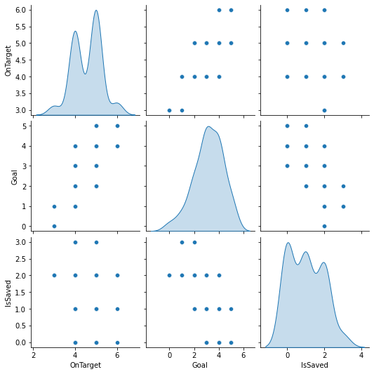

```python
sns.pairplot(distributions.iloc[:,:4], diag_kind='kde')
```

```python
encoded = pd.get_dummies(inp['Team'], drop_first=True)
```

```python
inp = pd.concat([inp, encoded], axis=1)
```

```python
inp.drop('Team', axis=1, inplace=True)
```

```python
inp
```

|  | OnTarget | Goal | IsSaved | Win | BEL | BRA | BUL | CHI | COL | CRA | ... | POR | ROM | RUM | RUS | SPA | SWE | SWZ | UKR | URU | YUG |
| --- | --- | --- | --- | --- | --- | --- | --- | --- | --- | --- | --- | --- | --- | --- | --- | --- | --- | --- | --- | --- | --- |
| 0 | 6 | 4 | 2 | 1 | 0 | 0 | 0 | 0 | 0 | 0 | ... | 0 | 0 | 0 | 0 | 0 | 0 | 0 | 0 | 0 | 0 |
| 1 | 6 | 5 | 1 | 0 | 0 | 0 | 0 | 0 | 0 | 0 | ... | 0 | 0 | 0 | 0 | 0 | 0 | 0 | 0 | 0 | 0 |
| 2 | 5 | 3 | 1 | 1 | 0 | 1 | 0 | 0 | 0 | 0 | ... | 0 | 0 | 0 | 0 | 0 | 0 | 0 | 0 | 0 | 0 |
| 3 | 5 | 4 | 0 | 0 | 0 | 0 | 0 | 0 | 0 | 0 | ... | 0 | 0 | 0 | 0 | 0 | 0 | 0 | 0 | 0 | 0 |
| 4 | 4 | 4 | 0 | 0 | 0 | 0 | 0 | 0 | 0 | 0 | ... | 0 | 0 | 0 | 0 | 0 | 0 | 0 | 0 | 0 | 0 |
| ... | ... | ... | ... | ... | ... | ... | ... | ... | ... | ... | ... | ... | ... | ... | ... | ... | ... | ... | ... | ... | ... |
| 65 | 4 | 4 | 0 | 1 | 0 | 0 | 0 | 0 | 0 | 0 | ... | 0 | 0 | 0 | 0 | 0 | 0 | 0 | 0 | 0 | 0 |
| 66 | 5 | 4 | 0 | 0 | 0 | 0 | 0 | 0 | 0 | 0 | ... | 0 | 0 | 0 | 0 | 0 | 0 | 0 | 0 | 0 | 0 |
| 67 | 5 | 3 | 2 | 1 | 0 | 0 | 0 | 0 | 0 | 0 | ... | 0 | 0 | 0 | 0 | 0 | 0 | 0 | 0 | 0 | 0 |
| 68 | 4 | 4 | 0 | 0 | 0 | 0 | 0 | 0 | 0 | 0 | ... | 0 | 0 | 0 | 0 | 0 | 0 | 0 | 0 | 0 | 0 |
| 69 | 4 | 2 | 1 | 1 | 0 | 0 | 0 | 0 | 0 | 0 | ... | 0 | 0 | 0 | 0 | 0 | 0 | 0 | 0 | 0 | 0 |

70 rows × 38 columns

Standardizing data using Minmax Scaler

```python
scaler = MinMaxScaler(feature_range=(-1, 1))
```

```python
tf = scaler.fit_transform(inp.drop('Win', axis=1))
```

```python
X = tf
```

```python
Y = inp['Win'].values
```

```python
Y.shape, X.shape
```

```
((70,), (70, 37))
```

```python
X_train, X_test, y_train, y_test = train_test_split(X, Y, test_size=0.3, random_state=101)
```

```python
KNN_agg = KNeighborsClassifier()
```

```python
KNN_agg.fit(X_train, y_train)
```

```
KNeighborsClassifier()
```

```python
pred_agg = KNN_agg.predict(X_test)
```

```python
print(30*'**')
print(confusion_matrix(y_test, pred_agg))
print(30*'**')
print(classification_report(y_test, pred_agg))
print(30*'**')
print(f"{accuracy_score(y_test, pred_agg):.2%}")
```

```
[[7 5]
 [4 5]]
              precision    recall  f1-score   support

           0       0.64      0.58      0.61        12
           1       0.50      0.56      0.53         9

    accuracy                           0.57        21
   macro avg       0.57      0.57      0.57        21
weighted avg       0.58      0.57      0.57        21

57.14%
```

```python
error_rate = []
for k in range(1, 41):
    KNN = KNeighborsClassifier(n_neighbors=k)
    KNN.fit(X_train, y_train)
    preds = KNN.predict(X_test)
    error_rate.append(np.mean(preds != y_test))


df_errors = pd.DataFrame({'K': range(1, 41),'Errors':error_rate})

df_errors.sort_values('Errors', ascending=True).head(5)
```

|  | K | Errors |
| --- | --- | --- |
| 14 | 15 | 0.142857 |
| 18 | 19 | 0.238095 |
| 8 | 9 | 0.238095 |
| 3 | 4 | 0.285714 |
| 12 | 13 | 0.285714 |

```python
KNN = KNeighborsClassifier(n_neighbors=15)
KNN.fit(X_train, y_train)
pred_agg = KNN.predict(X_test)
print(30*'**')
print(confusion_matrix(y_test, pred_agg))
print(30*'**')
print(classification_report(y_test, pred_agg))
print(30*'**')
print(f"{accuracy_score(y_test, pred_agg):.2%}")
```

```
[[12  0]
 [ 3  6]]
              precision    recall  f1-score   support

           0       0.80      1.00      0.89        12
           1       1.00      0.67      0.80         9

    accuracy                           0.86        21
   macro avg       0.90      0.83      0.84        21
weighted avg       0.89      0.86      0.85        21

85.71%
```

# PERFORMING A GRID SEARCH TO GET THE BEST PARAMETER COMBO

```python
from sklearn.model_selection import GridSearchCV
```

```python
KNN.get_params()
```

```
{'algorithm': 'auto',
 'leaf_size': 30,
 'metric': 'minkowski',
 'metric_params': None,
 'n_jobs': None,
 'n_neighbors': 15,
 'p': 2,
 'weights': 'uniform'}
```

```python
params={'n_neighbors':list(range(5, 25)),
        'metric':['euclidean','minkowski','manhattan'],
       'weights':['uniform','distance']}
```

```python
grid = GridSearchCV(KNN,param_grid=params,verbose=3)
```

```python
grid.fit(X_train, y_train)
```

[output not shown]

[output cut: 546 more lines]

[output not shown]

```
GridSearchCV(estimator=KNeighborsClassifier(n_neighbors=15),
             param_grid={'metric': ['euclidean', 'minkowski', 'manhattan'],
                         'n_neighbors': [5, 6, 7, 8, 9, 10, 11, 12, 13, 14, 15,
                                         16, 17, 18, 19, 20, 21, 22, 23, 24],
                         'weights': ['uniform', 'distance']},
             verbose=3)
```

```python
grid.best_params_
```

```
{'metric': 'euclidean', 'n_neighbors': 8, 'weights': 'distance'}
```

```python
grid_pred = grid.predict(X_test)
```

```python
print(30*'**')
print(confusion_matrix(y_test, grid_pred))
print(30*'**')
print(classification_report(y_test, grid_pred))
print(30*'**')
print(f"{accuracy_score(y_test, grid_pred):.2%}")
```

```
[[9 3]
 [3 6]]
              precision    recall  f1-score   support

           0       0.75      0.75      0.75        12
           1       0.67      0.67      0.67         9

    accuracy                           0.71        21
   macro avg       0.71      0.71      0.71        21
weighted avg       0.71      0.71      0.71        21

71.43%
```

```python
from sklearn.linear_model import LogisticRegression
```

```python
Log = LogisticRegression()
```

```python
Log.fit(X_train, y_train)
```

```
LogisticRegression()
```

```python
pred_log = Log.predict(X_test)
```

```python
print(confusion_matrix(y_test, pred_log))
print('**'* 30)
print(classification_report(y_test, pred_log))
```

```
[[9 3]
 [3 6]]
              precision    recall  f1-score   support

           0       0.75      0.75      0.75        12
           1       0.67      0.67      0.67         9

    accuracy                           0.71        21
   macro avg       0.71      0.71      0.71        21
weighted avg       0.71      0.71      0.71        21
```